# Milestone 6

Adelson Aguasvivas

March 20th, 2020

# About Draft

#### [Access my Github repository here!](https://github.com/aaguasvivas/MS_4)

For my final project, I want to focus on the history and effects of racism and discrimination, specifically through redlining. I will look at how redlining affected the geography of New York City, where I am from. I will be focusing on the five different boroughs (the Bronx, Queens, Manhattan, Brooklyn and Staten Island) and see how the city has been divided. I will use shapefile data from 1937-1940, to look at these divisions, which use different rankings to categorize geographical locations. These geographical locations were associated with race, with some of the “hazardous” zones often being those with the highest Black and Hispanic populations. I will be using census data to determine how those zones are still affected today, and what the change has been throughout the last 80 years. My expectation is that the zones that were redlined because of people of color will be some of the poorest places still today. I expect a lot of these areas to still have a high concentration of people of color. If not, I will look to see whether this change from being a city that was redlined, to now being more wealthy, is one of the results of gentrification. Right now, I have collected a lot of the map data through shapefiles, which I am not sure how to work with yet, and I am actively trying to learn about. I am using census data which we have worked with in class before. I am looking for other sorts of data that will help me prove my claim or give me some sort of guidance as to what kinds of observations I can make.

Right now, my plan is to examine this data and talk to my TF, Mitchell, to see what kinds of comparisons are useful when working with shapefile maps and census data. Something I am worried about and will keep working through is whether I am reading and processing this data correctly and whether I will be able to draw useful observations moving forward. As of right now, I will be using a lot of what I have mentioned here as part of my future About Page, as well as hopefully a lot of the data gathered into my raw-data subdirectory. I will be taking the datacamp course that focuses on using sf, as well as a few other courses, maybe around mapping.

# Datasets Used & Links

I used the following datasets:

- Mapping Inequality Redlining in New Deal America Shapefiles. [(here)](https://dsl.richmond.edu/panorama/redlining/#loc=6/37.484/-79.955&text=downloads)
  - This dataset provides us with accurate visuals of what readlining was like from 1937-1940, in the different parts of New York. We have access to several different parts of New York, but I have decided to focus on the five boroughs, not only because these are the places I am more familiar with being from New York, but also because this is where some of the worst redlining in the country happened about 80 years ago. I hope to explore this data and compare it to recent census data, to see which patterns and observations are relevant and important to discuss.
- New York City Census Data: Demographic, Economic, and Location Data for Census Tracts in NYC. [(here)](https://www.kaggle.com/muonneutrino/new-york-city-census-data/data)
  - This is the most recent census data I could find which provides huge amounts of information, such as where the people live, income levels, education, rate of poverty, income per capita, race, gender, among other things. I will use this information and compare it to the redlining maps from 80 years ago to see ouch patterns have developed because of redlining and how have people been affected by it even 80 years later.
- Tidycensus Library
  - I used some of the techniques we have learned in class, like get_acs, to plot the median income for the five boroughs in New York city in 2018, as well as each of their racial geographies.

# Progress Update Since Milestone 3:

To complete Milestone 4, I have started by duplicating my Milestone 3 repo, so that I can keep adding to it. I have included my raw data in the “raw-data” subdirectory, and will display some of the code and graphs I hope to be making below. I have included a description of the data I have collected and where it is located in the links above. I plan to compare maps and graphs of redlining from the years 1937 to 1940, comparing it to today, so that we can see the long term effects redlining, racism and discrimination have caused in New York City. I expect to see that most of the places where redlining occurred, are still either very poor, due to the government neglecting these areas, with Black and Latinx minorities making up most of the population, or are becoming gentrified in the case of some places in Brooklyn and elsewhere. I want to explore the impact these types of discriminatory policies have had on the lives of the residents, and how it has hurt them and caused their displacement. Below, I try to display the median income for each of the five boroughs in 2018, in hopes of comparing it to race and the redlining from 1937-1940s. Right now, I am struggling with getting a median income graph that is more detailed, showing the differences between the different parts of the boroughs, so that we can see the income of the areas that are majority Black and Latinx versus the mostly White areas, as that way it would also be easier to compare it to the Redlining graphs. Below I display the median income in 2018, as well as the racial geography of the five boroughs, from 2014-2018, which I got using the tidycensus library. I hope to combine and display this data, alongside the redlining maps and more detailed income data, for which I have a table called NY_census_tracts.

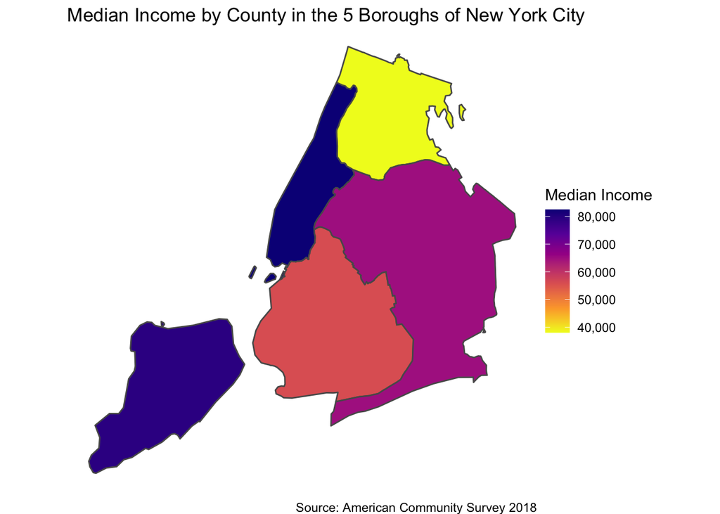

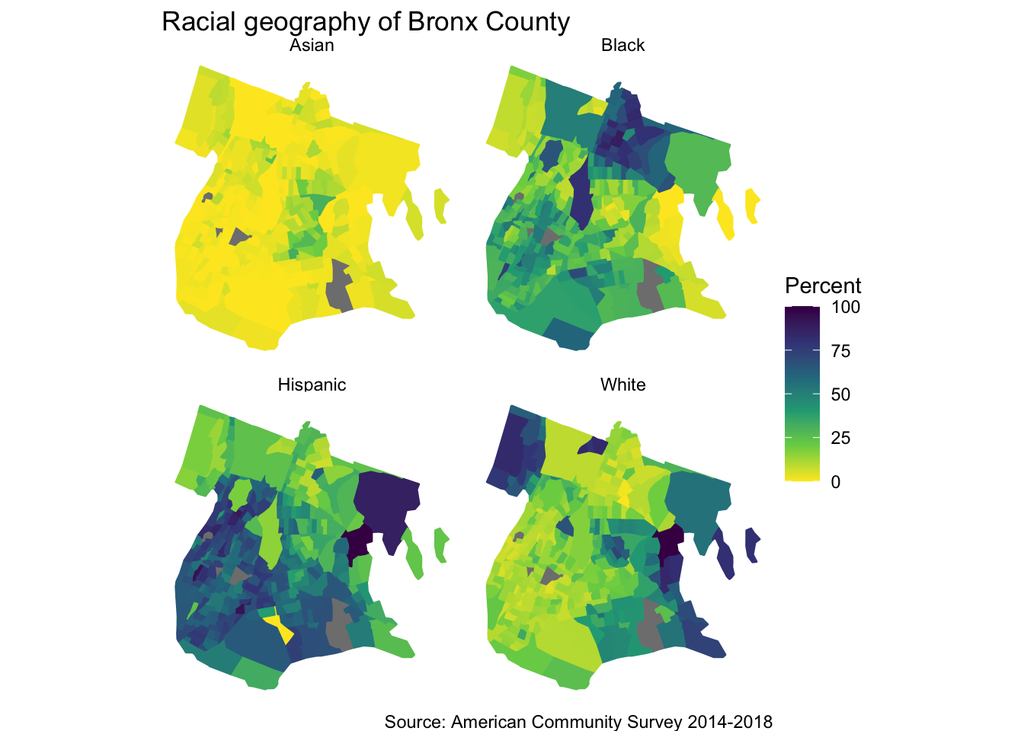

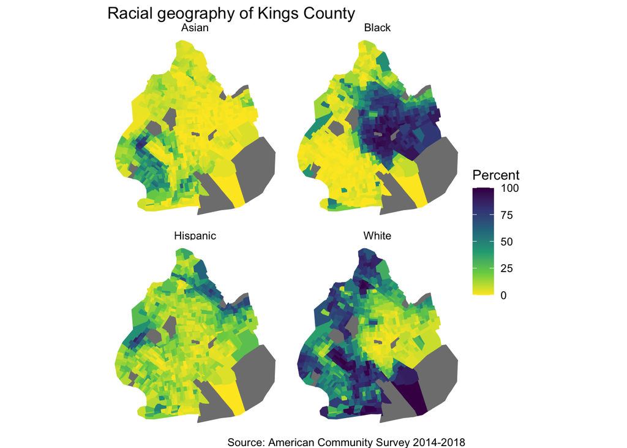

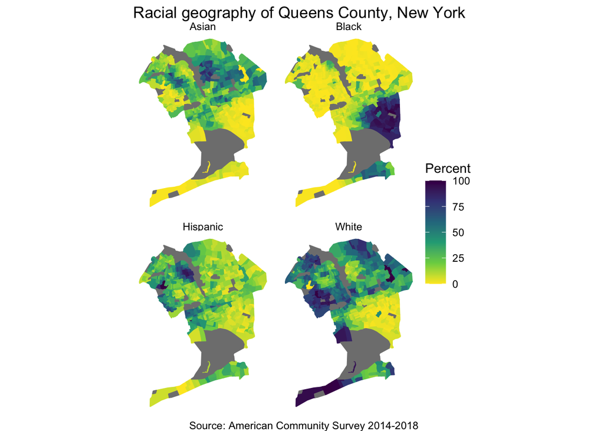

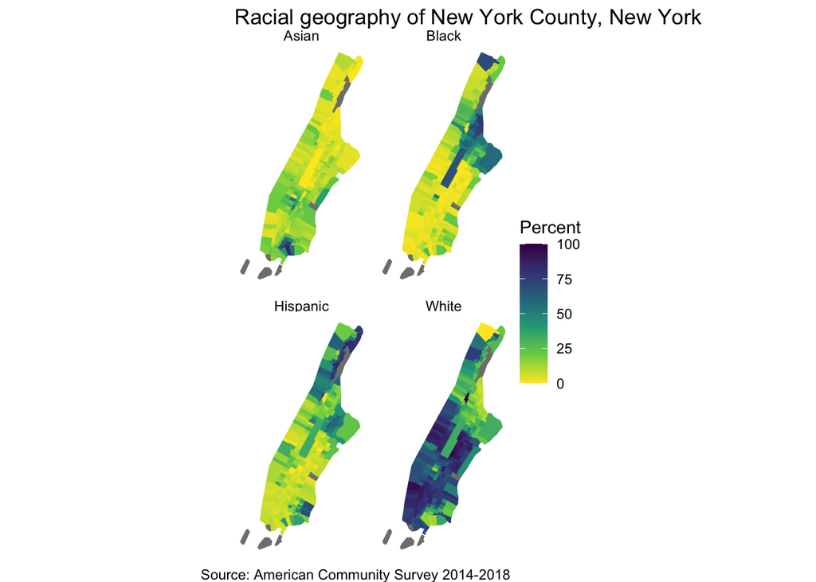

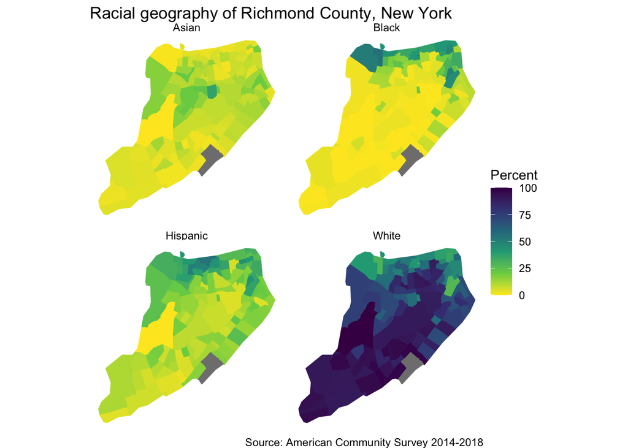

# Progress Update Since Milestone 4:

I will try to create another graph where I compare the change in the racial demographics of the five boroughs using webscrapped data from wikipedia, so that we can compare the different racial distributions and how this plays a part in median income. Right now, I am trying to collect as much data as possible and make the different graphs, so that I can see which are worth putting on the final product because they are accurate and informative and which are not. For this milestone, I have done the graph for the Bronx, New York.

**Link to RPubs: https://rpubs.com/aaguasvivas/bronx-change-demographics**

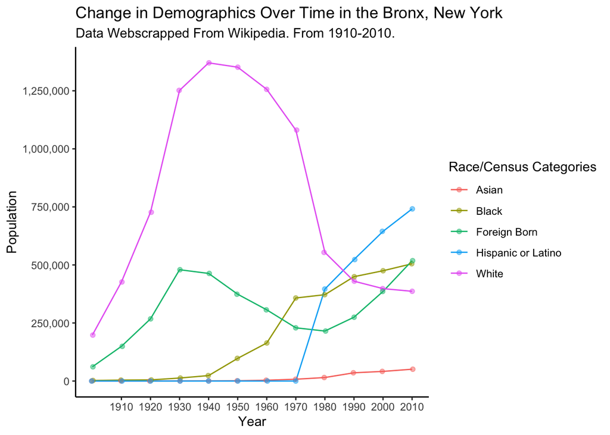

# Progress Update Since Milestone 5:

**LINK TO THE REPO: https://github.com/aaguasvivas/MS_6**

**LINK TO THE SHINY APP: https://adelson-aguasvivas.shinyapps.io/ms_6_change_over_time_bronx_animated/**